# Chapter 2. Regression and model validation.

Today is:

```r
date()
```

```
## [1] "Thu Nov  5 00:02:28 2020"
```

#### Task 1. Read and explore the data.

Reading data from local directory.

```r
students2014<-read.table(file="data/learning2014.txt",header=T, sep="\t")
```

Success! Let’s check the data structure using **R** functions **dim** and **str**.

```r
dim(students2014)
```

```
## [1] 166   7
```

```r
str(students2014)
```

```
## 'data.frame':    166 obs. of  7 variables:
##  $ gender  : chr  "F" "M" "F" "M" ...
##  $ Age     : int  53 55 49 53 49 38 50 37 37 42 ...
##  $ Attitude: int  37 31 25 35 37 38 35 29 38 21 ...
##  $ deep    : num  3.58 2.92 3.5 3.5 3.67 ...
##  $ stra    : num  3.38 2.75 3.62 3.12 3.62 ...
##  $ surf    : num  2.58 3.17 2.25 2.25 2.83 ...
##  $ Points  : int  25 12 24 10 22 21 21 31 24 26 ...
```

The data has 7 variables from 166 students. Variables **deep**, **strategic** and **surface** learning were created based on survey done in 2014. Method to calculate variables is described [here](https://www.mv.helsinki.fi/home/kvehkala/JYTmooc/JYTOPKYS2-meta.txt). Rest variables are **gender**, **Age**, global **Attitude** towards statistics, and final exam **Points**.

#### Task 2. Graphcal overview of the data.

Inbuild **R** function **plot** quite ugly. Therefore I would use [ggplot2](https://ggplot2.tidyverse.org/reference/ggplot.html) as much elegant way to overview the data.

Let’s access ggplot package first.

```r
library(ggplot2)
```

[GGally](https://ggobi.github.io/ggally/) package will be useful also.

```r
library(GGally)
```

Now let’s create pairwise plot presenting relationships among variables.

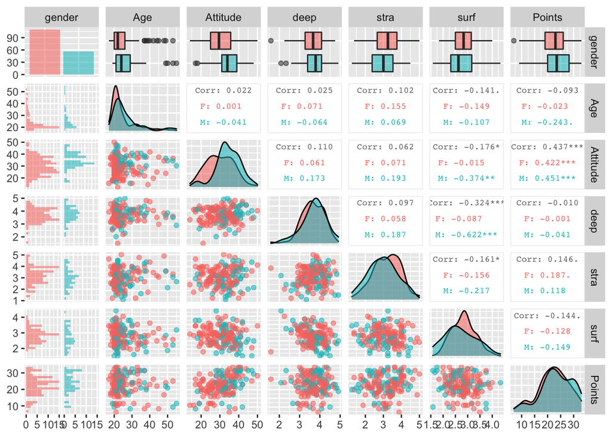

```r
ggpairs(students2014, mapping = aes(col=gender,alpha=0.3), lower = list(combo = wrap("facethist", bins = 20)),upper = list(continuous = wrap("cor", size = 2.5)))
```

summary of the data

```r
summary(students2014)
```

```
##     gender               Age           Attitude          deep
##  Length:166         Min.   :17.00   Min.   :14.00   Min.   :1.583
##  Class :character   1st Qu.:21.00   1st Qu.:26.00   1st Qu.:3.333
##  Mode  :character   Median :22.00   Median :32.00   Median :3.667
##                     Mean   :25.51   Mean   :31.43   Mean   :3.680
##                     3rd Qu.:27.00   3rd Qu.:37.00   3rd Qu.:4.083
##                     Max.   :55.00   Max.   :50.00   Max.   :4.917
##       stra            surf           Points
##  Min.   :1.250   Min.   :1.583   Min.   : 7.00
##  1st Qu.:2.625   1st Qu.:2.417   1st Qu.:19.00
##  Median :3.188   Median :2.833   Median :23.00
##  Mean   :3.121   Mean   :2.787   Mean   :22.72
##  3rd Qu.:3.625   3rd Qu.:3.167   3rd Qu.:27.75
##  Max.   :5.000   Max.   :4.333   Max.   :33.00
```

Number of Female students in the data was larger then Males. The mean students age was 25.51 and the oldest student - 55 years old. Worth to check standard deviation.

```r
sd(students2014$Age)
```

```
## [1] 7.766078
```

The maximum earned exam point was 33, all student’s average was 22.72. According to ggpairs plot, most of the variables have normal distribution. The students attitude highly correlated with Exam points. No dependency was found between points and gender or age.  
The negative correlation with exam points was observed in deep and surf variables. In opposite strategic learning positively correlated with exam points. Let’s build linear model…

#### Task 3. Linear model.

Explanatory variables I choose in a first run were attitude, deep, strategic and surface leanings.

The model had look:

```r
model=lm(Points~Attitude+stra+deep+surf, students2014)
summary(model)
```

```
##
## Call:
## lm(formula = Points ~ Attitude + stra + deep + surf, data = students2014)
##
## Residuals:
##      Min       1Q   Median       3Q      Max
## -16.7335  -3.1992   0.7975   3.4002  11.6582
##
## Coefficients:
##             Estimate Std. Error t value Pr(>|t|)
## (Intercept) 15.39999    5.02450   3.065  0.00255 **
## Attitude     0.34362    0.05739   5.987 1.34e-08 ***
## stra         0.88475    0.54110   1.635  0.10398
## deep        -1.00721    0.78702  -1.280  0.20247
## surf        -0.91045    0.83901  -1.085  0.27948
## ---
## Signif. codes:  0 '***' 0.001 '**' 0.01 '*' 0.05 '.' 0.1 ' ' 1
##
## Residual standard error: 5.286 on 161 degrees of freedom
## Multiple R-squared:  0.2154, Adjusted R-squared:  0.1959
## F-statistic: 11.05 on 4 and 161 DF,  p-value: 6.057e-08
```

Only Attitude here pass significance test in this model. The value 1.34e-08 *** in Pr(>|t|) column.

I have tried different models and find out that only Attitude has a significant relationship with exam points.

Perfect model is:

```r
perfect_model<-lm(Points~Attitude, students2014)
summary(perfect_model)
```

```
##
## Call:
## lm(formula = Points ~ Attitude, data = students2014)
##
## Residuals:
##      Min       1Q   Median       3Q      Max
## -16.9763  -3.2119   0.4339   4.1534  10.6645
##
## Coefficients:
##             Estimate Std. Error t value Pr(>|t|)
## (Intercept) 11.63715    1.83035   6.358 1.95e-09 ***
## Attitude     0.35255    0.05674   6.214 4.12e-09 ***
## ---
## Signif. codes:  0 '***' 0.001 '**' 0.01 '*' 0.05 '.' 0.1 ' ' 1
##
## Residual standard error: 5.32 on 164 degrees of freedom
## Multiple R-squared:  0.1906, Adjusted R-squared:  0.1856
## F-statistic: 38.61 on 1 and 164 DF,  p-value: 4.119e-09
```

#### Task 4. Explain the summary.

Residuals are not symmetrically distributed. Alpha parameter is 11.63 Effect of attitude on examine point is 0.352 with standard error 0.056. P test was 4^10-9, which shows significant relationship between target and explanatory variables. Roughly 19% examine Points variance was explained by Attitude variable, according to R2.

#### Task 5. Diagnostic plots.

Let’s create diagnostic plots.

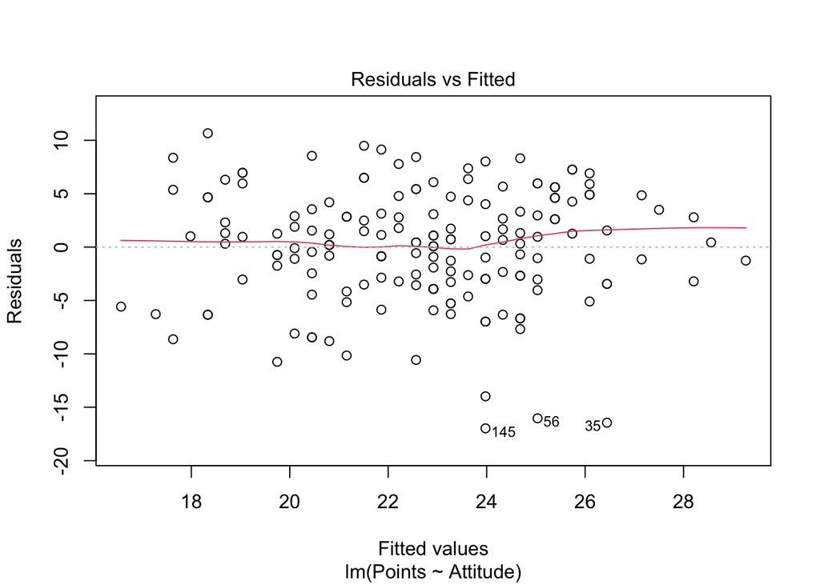

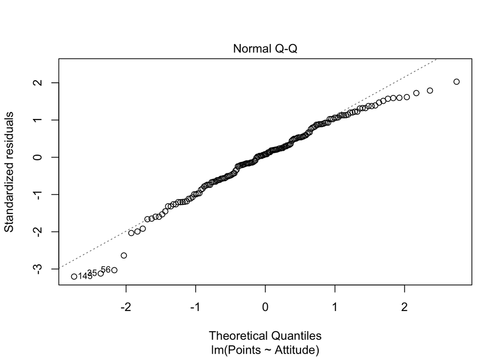

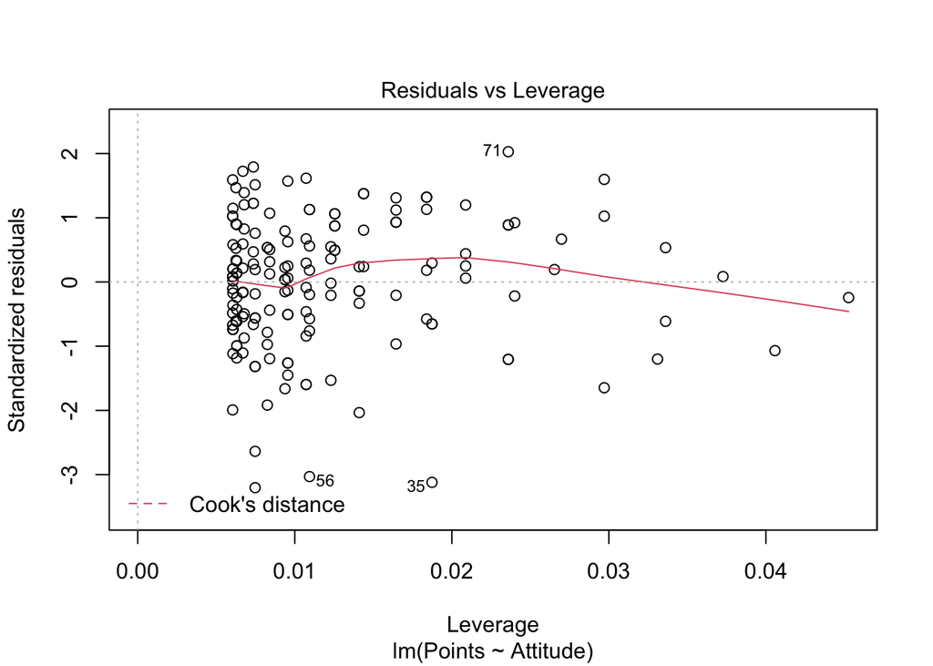

```r
plot(perfect_model,which=c(1,2,5))
```

Scatter plot of Residual vs Fitted values presenting random spread of points. This means that variance has constant variance. No abnormall pattern was detected.

Normality Q-Q plot presenting distribution of model errors. Slight deviation is seen at the beginning and the end of the line. But generally speaking errors are normally distributed as they following line.

Residuals vs Leverage plot showing absence of outspending observations in the linear model.

All three plots are supporting model linearity assumption and normal distribution of errors.